# Image Segmentation Assignment

## Image Segmentation Assignment

#### Name: Arnab Mukherjee Roll No: MB1908

#### Theory:

In digital image processing and computer vision, image segmentation is the process of partitioning a digital image into multiple segments (sets of pixels, also known as image objects). The goal of segmentation is to simplify and/or change the representation of an imae into something that is more meaningful and easier to analyze. Image segmentation is typically used to locate objects and boundaries in images. More precisely , image segmentation is the process of assigning a label to every pixel in an image suchg that pixels with same label share certain characteristics.

#### Groups of image segmentation:

- **Semantic segmentation** is an approach detecting, for every pixel, belonging class of the object. For example, when all people in a figure are segmented as one object and background as one object.
- **Instance Segmentation** is an approach that identifies , for every pixel , a belonging instance of the object. It detects each distinct object of interest in the image. For example, when each person in a figure is segmented as an individual object.

#### Thresholding:

Thresholding is the simplest method of segmenting images. From grayscale image thresholding can be used to create binary images. The simplest thresholding methods replace each pixel in an image with a black pixel if the image intensity $I_{i,j} \leq T$ where T is some fixed constant. We will use this simple thresholding technique on a grayscale image.

###### Importing Libraries

```python
import cv2
import numpy as np
import matplotlib.pyplot as plt
import matplotlib.image as mpimg
from PIL import Image
```

```python
#Function to convert RGB to Grayscale
def rgb2gray(rgb):
    return np.dot(rgb[...,:3], [0.2989, 0.5870, 0.1140])
```

###### Reading the Image File

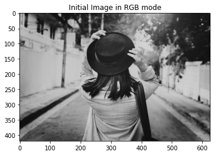

```python
image = cv2.imread("pic1.jpg")
plt.imshow(image,cmap = 'gray')
plt.title("Initial Image in RGB mode")
plt.show()
```

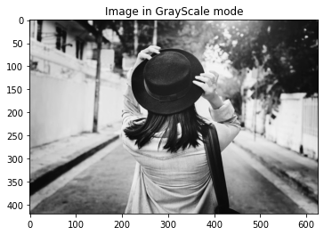

```python
image = rgb2gray(image)
plt.imshow(image,cmap = 'gray')
plt.title("Image in GrayScale mode")
plt.show()
```

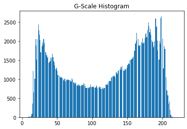

```python
plt.hist(image.ravel(),bins = 255)
plt.title("G-Scale Histogram")
plt.show()
```

From the histogram we can clearly see that there are two class in the image. One is the foreground and the other one is the background

##### Thresholding Function:

```python
def s2(image,threshold):
    image = np.array(image) #here we convert the image to an array
    l1 = len(image)
    l2 = len(image[0])
    for i in range(l1):
        for j in range(l2):
            if image[i][j] > threshold:
                image[i][j] = 255
            else:
                image[i][j] = 0
    im = Image.fromarray(image) #converting the array back to image
    return im #returning the image
```

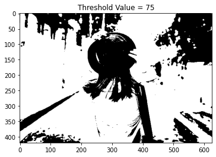

```python
plt.imshow(s2(image,75),cmap = 'gray')
plt.title("Threshold Value = 75")
```

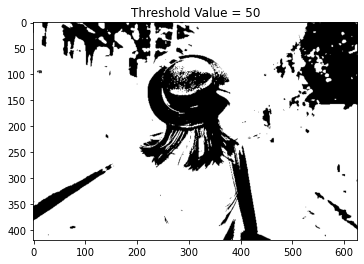

```python
plt.imshow(s2(image,50),cmap = 'gray')
plt.title("Threshold Value = 50")
```

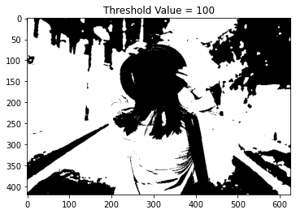

```python
plt.imshow(s2(image,100),cmap = 'gray')
plt.title("Threshold Value = 100")
```

##### A better Way to detect the thresholding Value:

Although the previous method is useful one down side is we have to guess the thresholding value. If we use **Otsu's algorithm** we can do it automatically. The algorithm exhaustively searches for the threshold that minimizes the intra-class variance, defined as a weighted sum of variances of the two classes

```python
def otsu(img):
    var = np.zeros(256)
    freq = np.zeros(256)
    for i in range(img.shape[0]):
        for j in range(img.shape[1]):
            freq[int(img[i][j])] += 1

    for s in range(1, 255):
        w1 = freq[0:s].sum()
        w2 = freq[s:].sum()
        if w1!=0 and w2!= 0:
            mu1 = sum( np.arange(s) * freq[0:s] ) / w1
            mu2 = sum( np.arange(s, 256) * freq[s:] ) / w2
            var[s] = w1 * w2 * ((mu1 - mu2)**2)

    return var
```

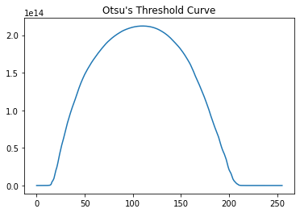

```
Optimal Thresholding value = 110
```

```python
var = otsu(image)
plt.plot(var)
plt.title("Otsu's Threshold Curve")
plt.show()
print("Optimal Thresholding value = " + str(np.argmax(var)))
```

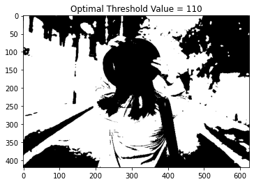

```python
plt.imshow(s2(image,110),cmap = 'gray')
plt.title("Optimal Threshold Value = 110")
```